# Reproducible Research: Peer Assessment 2

Health and Economic Impact of Severe Weather in the US, 1996-2011

Greg Verissimo

# 1 Synopsis

This paper uses NOAA’s [Storm Events Database](https://www.ncdc.noaa.gov/stormevents/details.jsp) to analyze the impact of severe weather events on the US and its territores, and more specifically to answer the following questions:

1. Which types of severe weather events are the most harmful with respect to population health?
2. Which types of severe weather events have the greatest economic consequences?

1. **WFO** : The National Weather Service operates 122 weather forecast offices (WFO) across the US and its territores which issue severe weather warnings, gather weather observations, and daily and monthly climate data for their assigned areas.
2. **EVTYPE** : While there are only 55 official Event Types (see appendix), in actuality the database contains nearly 1000 different types.
3. **BGN_DATE, BGN_TIME** : Beginning date and time of each storm event.
4. **PROPDMG, PROPDMGEXP** : Property damage resulting freom each storm event including damage to both private property as well as public infrastructure and facilities.
5. **CROPDMG, CROPDMGEXP** : Crop damage resulting from each storm event.
6. **INJURIES, FATALITIES** : Injuries and fatalities resulting from each storm event.

Source dataset :

# 2 Data Processing

## 2.1 Load required packages

```r
## Load  libraries
library(R.utils)
library(lubridate)
library(dplyr)
library(tidyr)
library(ggplot2)
library(RColorBrewer)
```

## 2.2 Download datasets from the Internet

```r
## download and decompress raw data
if (!file.exists("./data/repdata-data-StormData.csv.bz2")) {
        download.file("https://d396qusza40orc.cloudfront.net/repdata%2Fdata%2FStormData.csv.bz2",
                      destfile = "./data/repdata-data-StormData.csv.bz2",
                      method = "curl"
                      )
        bunzip2("./data/repdata-data-StormData.csv.bz2", "./data/repdata-data-StormData.csv",
                remove = FALSE,
                skip = TRUE
                )
}


if (!file.exists("./data/NWS_WFO_ID.txt")) {
        download.file("https://www.spc.noaa.gov/misc/NWS_WFO_ID.txt",
                      destfile = "./data/NWS_WFO_ID.txt",
                      method = "curl"
        )
}
```

## 2.3 Load WFO Information

Import NOAA/NWS WFO information into a datafram and do some some basic cleanup  
*(e.g. - replace tabs with commas, remove extra spaces, etc.)*

```r
## import NWS Weather Forecast (WFO) data
NwsInfoId_raw <- readLines("./data/NWS_WFO_ID.txt")    ## load WFO ID text file
NwsInfoId_raw <- NwsInfoId_raw[-c(1:2)]                ## trim off first two title lines

## clean NWS WFO info
NwsInfoId_list <- NwsInfoId_raw %>%
        gsub(pattern = "\t+", replace = ",") %>%
        gsub(pattern = ", +", replace = ",") %>%
        strsplit(",")
## ...and convert to dataframe
NwsInfoId <- as.data.frame(
        matrix(unlist(NwsInfoId_list), ncol=3, byrow=TRUE )
        )
names(NwsInfoId) = c("City", "State", "WFO")
## print(NwsInfoId)  ## debug
```

## 2.4 Load and Tidy Storm Incident Dataset

Import the NOAA/NCDC *Storm Events Database* into dataframe then subset and tidy the dataset by merging date & time, crop damage & exponent, property damage & exponent, etc.

```r
## import storm incident dataset
stormData_raw <- read.csv(file = "./data/repdata-data-StormData.csv",
                          sep = ",",
                          header=TRUE,
                          stringsAsFactors = FALSE
                          )

## first subset and tidy up the dataset
stormData <- stormData_raw %>%
        ## subset the variables we'll be using for the analysis
        select(WFO, EVTYPE, BGN_DATE, BGN_TIME,
               PROPDMG, PROPDMGEXP, CROPDMG, CROPDMGEXP,
               INJURIES, FATALITIES
               ) %>%

        ## replace missing WFO with NA
        mutate(
                WFO = ifelse(WFO=="", NA_character_, WFO)
        ) %>%

        ## uppercase event types and rename the variable
        mutate(EVTYPE = toupper(EVTYPE)) %>%
        rename(EventType = EVTYPE) %>%

        ## clean up event start date and combine date & time into a single variable
        separate(BGN_DATE, c("BGN_DATE", NA), sep="[ ]") %>%  ## discard dangling "0:00:00"
        ## combine date/time strings and convert to date
        mutate(
                EventStart = paste(BGN_DATE, " ",
                                   substr(BGN_TIME,1,2), ":",
                                   substr(BGN_TIME,3,4),":00",
                                   sep=""),
                EventStart = mdy_hms(EventStart)
        ) %>%
        ## ...drop the old variables
        select(-c(BGN_DATE, BGN_TIME)) %>%

        ## combine (PROPDMGePROPDMGEXP and CROPDMGeCROPDMGEXP) into numbers
        mutate(
                PropertyDamage = PROPDMG*recode(toupper(PROPDMGEXP),
                                      "H"=10^2, "K"=10^3, "M"=10^6, "B"=10^9,
                                      "0"=1, "1"=10, "2"=10^2, "3"=10^3, "4"=10^4, "5"=10^5,
                                      "6"=10^6, "7"=10^7, "8"=10^8,
                                      "+"=1, "-"=1, .default=NA_real_),
                CropDamage = CROPDMG*recode(toupper(CROPDMGEXP),
                                      "H"=10^2, "K"=10^3, "M"=10^6, "B"=10^9,
                                      "0"=1, "1"=10, "2"=10^2, "3"=10^3, "4"=10^4, "5"=10^5,
                                      "6"=10^6, "7"=10^7, "8"=10^8,
                                      "+"=1, "-"=1, .default=NA_real_),
                ## for later ordering, sum propertyDamage + cropDamage
                PropertyAndCropDamage = ifelse(!is.na(PropertyDamage), PropertyDamage, 0) +
                        ifelse(!is.na(CropDamage), CropDamage, 0),

        ) %>%
        ## ...and drop the old variables
        select(-c(PROPDMG, PROPDMGEXP, CROPDMG, CROPDMGEXP)) %>%

        ## similarly combine fatalities and inturies into fatalitiesAndInjuries
        mutate(
                FatalitiesAndInjuries = ifelse(!is.na(FATALITIES), FATALITIES, 0) +
                        ifelse(!is.na(INJURIES), INJURIES, 0)
        ) %>%
        ## and rename injuries & fatalities ...just cuz I dislike allcaps
        rename(Injuries = INJURIES) %>%
        rename(Fatalities = FATALITIES)
## summary(stormData$PropertyAndCropDamage)  ## debug
## summary(stormData$FatalitiesAndInjuries)  ## debug
```

## 2.5 Consolidate Event Classifications

Across the 900,000+ events contained in the dataset, there are nearly 1000 unique weather event classifications –including quite a few data entry errors.

In order to get a high level view of the impacts across the various categories of severre weather events, we chose to consolidate those 900+ event classificaitons into just 20 broad categories:

1. Cold
2. Heat
3. Drought
4. Dust
5. Fire / Smoke
6. Water / Flood
7. Hurricane / Tropical Storm
8. Thunder / Lightning
9. Tornado / Waterspout
10. Rain
11. Snow / Ice
12. High Surf / Tide
13. Earthquake / Tsunami
14. Avalanche
15. High Winds
16. Erosion / Landslide
17. Fog
18. Dam Failure
19. Volcano
20. *other*

```r
## Consolidate and clean storm event descriptions
stormData <- stormData %>%
        mutate(EventType = case_when(
                grepl("COLD|WINDCHILL|COOL|WINTER WEATHER", EventType) ~ "Cold",
                grepl("HEAT|WARM|HOT|DRY", EventType) ~ "Heat",
                grepl("DROUGHT|DRY|LOW RAINFALL", EventType) ~ "Drought",
                grepl("DUST", EventType) ~ "Dust",
                grepl("FIRE|SMOKE", EventType) ~ "Fire / Smoke",
                grepl("FLOOD|FLD|FLDG|FLOOOD|SURGE|HIGH WATER|SEICHE", EventType) ~ "Water / Flood",
                grepl("HURRICANE|CYCLONE|TYPHOON|TROPICAL STORM|TROPICAL DEPRESSION", EventType) ~  "Hurricane / Tropical Storm",
                grepl("TSTM|THUNDERSTORM|LIGHTNING|LIGHTING|LIGNTNING", EventType) ~ "Thunder / Lightning",
                grepl("TORNADO|TORNDAO|FUNNEL|GUSTNADO|WATERSPOUT", EventType) ~ "Tornado / Waterspout",
                grepl("RAIN|SHOWER|WET|DOWNBURST|PRECIPITATION|HEAVY MIX", EventType) ~ "Rain",
                grepl("SNOW|BLIZZARD|AVALANCHE|AVALANCE|ICE|ICY|FROST|FREEZE|FREEZING|GLAZE|HAIL|SLEET|FREEZING RAIN|WINTER STORM", EventType) ~ "Snow / Ice",
                grepl("SURF|CURRENT|TIDE|TIDAL FLOOD|COASTAL|FLOOD", EventType) ~ "High Surf / Tide",
                grepl("EARETHQUAKE|TSUNAMI", EventType) ~ "Earthquake / Tsunami",
                grepl("AVALANCHE|AVALANCE", EventType) ~ "Avalanche",
                grepl("WIND|MICROBURST", EventType) ~ "High Winds",
                ## lower priority classifications
                grepl("EROSION|EROSIN|SLIDE|SLUMP", EventType) ~ "Erosion / Landslide",
                grepl("FOG", EventType) ~ "Fog",
                grepl("DAM", EventType) ~ "Dam Failure",
                grepl("VOLCANO|VOLCANIC", EventType) ~ "Volcano",
                is.na(EventType) ~ NA_character_,
                TRUE ~ "<other>"
                )
        )
```

## 2.6 Select Years for Analysis

In the early years of the dataset, very few severe weather events were captured. For example in 1951, the first full year of the dataset, there were less than 250 recorded events. Ten years later there were still only about 2,000 recorded events. In contrast, during the last year of the dataset (2011) there were more than 60,000 recorded events.

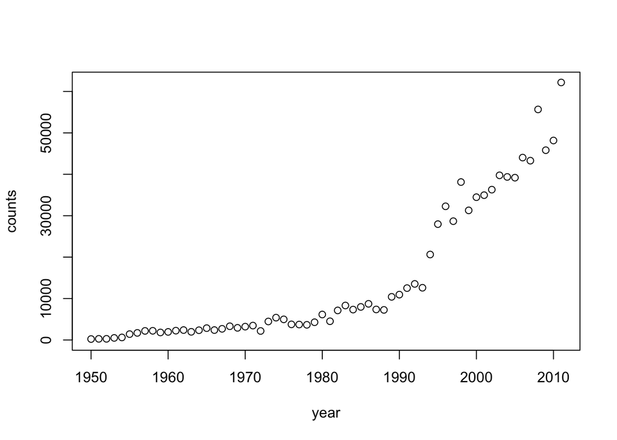

```r
## assess which years to utilize for the analysis
stormDates <- data.frame(EventStart=stormData$EventStart)
stormDates <-stormDates %>%
        group_by(year=floor_date(EventStart, "year")) %>%
        summarize(counts=n())
plot(stormDates)
```

Identify first target year (≥30,000 events) and subset the dataset (≥1996).

```r
## looking at the plot, e see what appears to be an exponential curve but with significant
## jump above 30k events per year starting in the late 1990's -- specifically: 1996
## specifically:
stormDates %>%
        filter(counts>=30000) %>%
        head(n=1)
```

```
## # A tibble: 1 x 2
##   year                counts
##   <dttm>               <int>
## 1 1996-01-01 00:00:00  32270
```

```r
## and filter stormData
targetStormData <- stormData %>% filter(EventStart >= as_date("1996-01-01 00:00:00"))
```

# 3 Results

## 3.1 Health Impact of Severe Weather Events

As you can see in the following chart, while the greatest number of deaths occur during periods of extreme heat, by a large margin the greatest health toll are due to tornadoes / waterspouts – more thn thunderstorms and floods combined.

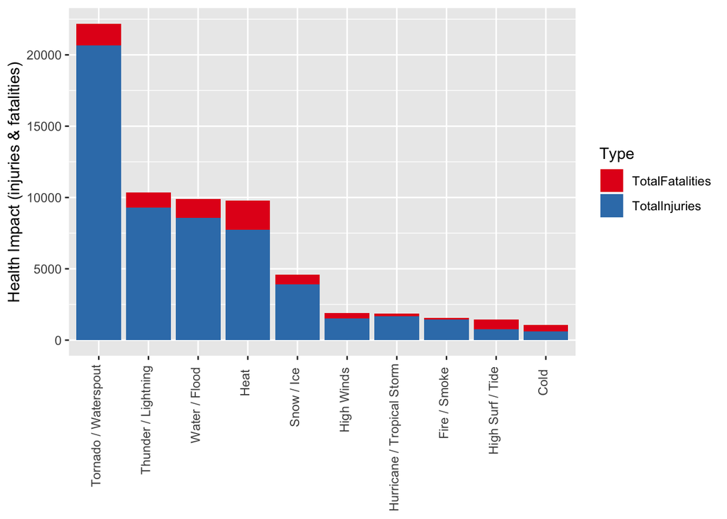

```r
healthImpact <- targetStormData %>%
        select(EventType, Injuries, Fatalities, FatalitiesAndInjuries) %>%
        group_by(EventType) %>%
        summarise(
                TotalInjuries = sum(Injuries, na.rm = TRUE),
                TotalFatalities = sum(Fatalities, na.rm = TRUE),
                TotalFatalitiesAndInjuries = TotalInjuries + TotalFatalities
        ) %>%
        arrange(desc(TotalFatalitiesAndInjuries)) %>%
        head(10) ## %>% print()

healthImpact %>%
        ## for sorting the bars, convert eventType to factors
        mutate(EventType = factor(EventType, levels = EventType[order(-TotalFatalitiesAndInjuries)])) %>%
        ## reshape data to long form for plotting
        gather(Type, HealthImpact, TotalInjuries:TotalFatalities) %>%
        ## and plot
        ggplot(aes(fill=Type, y=HealthImpact, x=EventType)) +
        geom_bar( stat="identity") +
        scale_fill_brewer(palette="Set1") +
        labs(y = "Health Impact (injuries & fatalities)") +
        theme(axis.text.x=element_text(angle=90, hjust=0.95, vjust = 0.2),
              axis.title.x = element_blank(),
        )
```

## 3.2 Economic Impact of Severe Weather Events

As you can see in the following chart, the greatest economic toll is due to water/flooding –more than all other categories combined.

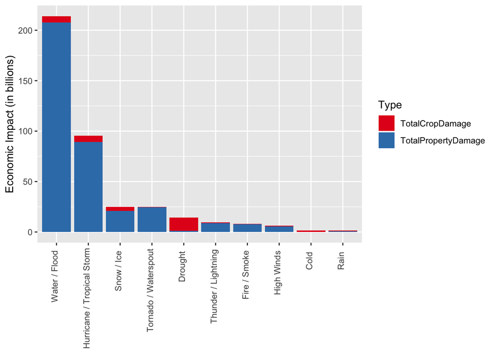

```r
## summarize economic impact
economicImpact <- targetStormData %>%
        select(EventType, PropertyDamage, CropDamage, PropertyAndCropDamage) %>%
        group_by(EventType) %>%
        summarise(
                TotalPropertyDamage = sum(PropertyDamage, na.rm = TRUE)/10^9,
                TotalCropDamage = sum(CropDamage, na.rm = TRUE)/10^9,
                TotalPropertyAndCropDamage = TotalPropertyDamage + TotalCropDamage
                ) %>%
        arrange(desc(TotalPropertyAndCropDamage)) %>%
        head(10) ## %>% print()

economicImpact %>%
        ## for sorting the bars, convert eventType to factors
        mutate(EventType = factor(EventType, levels = EventType[order(-TotalPropertyAndCropDamage)])) %>%
        ## reshape data to long form for plotting
        gather(Type, Damage, TotalPropertyDamage:TotalCropDamage) %>%
        ## and plot
        ggplot(aes(fill=Type, y=Damage, x=EventType)) +
        geom_bar( stat="identity") +
        scale_fill_brewer(palette="Set1") +
        labs(y = "Economic Impact (in billions)") +
        theme(axis.text.x=element_text(angle=90, hjust=0.95, vjust = 0.2),
              axis.title.x = element_blank(),
              )
```

# 4 Conclusion

Across the United States and its territories:

1. By a wide margin, Tornadoes have the greatest health impact in terms of injuries and fatalities.
2. By an even wider margin, the greatest economic toll is inflicted by water/flooding.

# 5 Appendices

## 5.1 List of Official Severe Weather Types

| Astronomical Low Tide | Excessive Heat | High Surf | Marine Hurricane/Typhoon | Strong Wind |  |
| --- | --- | --- | --- | --- | --- |
| Avalanche | Extreme Cold/Wind Chill | High Wind | Marine Lightning | Thunderstorm Wind |  |
| Blizzard | Flash Flood | Hurricane (Typhoon) | Marine Strong Wind | Tornado |  |
| Coastal Flood | Flood | Ice Storm | Marine Thunderstorm Wind | Tropical Depression |  |
| Cold/Wind Chill | Frost/Freeze | Lake-Effect Snow | Marine Tropical Depression | Tropical Storm |  |
| Debris Flow | Funnel Cloud | Lakeshore Flood | Marine Tropical Storm | Tsunami |  |
| Dense Fog | Freezing Fog | Lightning | Rip Current | Volcanic Ash |  |
| Dense Smoke | Hail | Marine Dense Fog | Seiche | Waterspout |  |
| Drought | Heat | Marine Hail | Sleet | Wildfire |  |
| Dust Devil | Heavy Rain | Marine Heavy Freezing Spray | Sneaker Wave | Winter Storm |  |
| Dust Storm | Heavy Snow | Marine High Wind | Storm Surge/Tide | Winter Weather |  |

## 5.2 List of Weather Forecast Offices (WFO)

| Albuquerque | NM | ABQ |
| --- | --- | --- |
| Aberdeen | SD | ABR |
| Anchorage | AK | AFC |
| Fairbanks | AK | AFG |
| Juneau | AK | AJK |
| Wakefield | VA | AKQ |
| Albany | NY | ALY |
| Amarillo | TX | AMA |
| Anchorage | AK | ANC |
| Gaylord | MI | APX |
| La Crosse | WI | ARX |
| Binghamton | NY | BGM |
| Bismarck | ND | BIS |
| Birmingham | AL | BMX |
| Boise | ID | BOI |
| Denver/Boulder | CO | BOU |
| Boston | MA | BOX |
| Brownsville | TX | BRO |
| Burlington | VT | BTV |
| Buffalo | NY | BUF |
| Billings | MT | BYZ |
| Columbia | SC | CAE |
| Caribou | ME | CAR |
| Charleston | SC | CHS |
| Cleveland | OH | CLE |
| Corpus Christi | TX | CRP |
| State College | PA | CTP |
| Cheyenne | WY | CYS |
| Dodge City | KS | DDC |
| Duluth | MN | DLH |
| Des Moines | IA | DMX |

[output cut: 92 more lines]